# On Logistic Function in Statistics and Machine Learning

Serafim Petrov Email: serafim.petrov@yahoo.com

2025-10-21

## Problem statement

Logistic regression is a widely used statistical technique to estimate the effect of variables on a binary outcome. The underlying function is also used in machine learning as an activation function, commonly called the sigmoid function, and forms the basis for classification methods known as logistic classifiers.

But what is the origin of this fundamental function?

This article explores the logistic differential equation, the general logistic function, its application in logistic regression, and maximum likelihood estimation for machine learning classifiers.

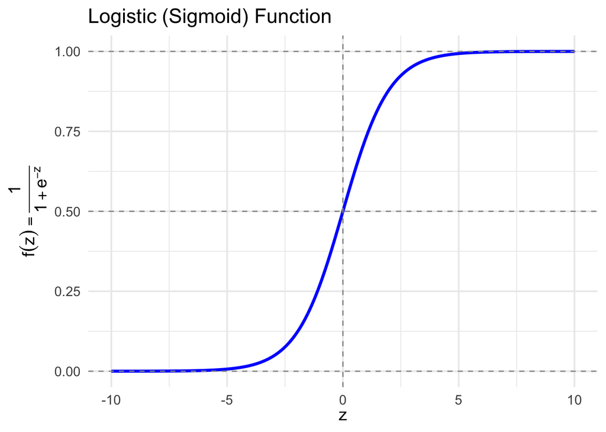

### The logistic differential equation

The logistic equation is a type of ordinary differential equation (ODE), introduced in the mid 1830s by Pierre François Verhulst[1].The logistic differential equation models population growth constrained by limited resources. The population is assumed to be the difference of the population birth rate and death rate in terms of per capita figures, and it is proportional to the current population with an assumption of resource limitation.

With several assumptions and algebraic operations to arrange the constants, it is given by:

$$\frac{dP}{dt} = r P \left(1 - \frac{P}{K}\right)$$

where:

- $P(t)$ is the population size at time $t$,
- $r$ is the intrinsic growth rate,
- $K$ is the carrying capacity, representing the maximum sustainable population.

This equation states that the growth rate is proportional to both the current population and the fraction of available resources left, $1 - \frac{P}{K}$. When the population is small compared to $K$, growth is approximately exponential. As the population approaches $K$, growth slows and eventually stops.

### The general logistic function

To derive the general solution, solve the differential equation:

$$\frac{dP}{dt} = r P \left(1 - \frac{P}{K}\right)$$

Separate variables:

$$\frac{dP}{P \left(1 - \frac{P}{K}\right)} = r \, dt$$

Rewrite denominator:

$$P \left(1 - \frac{P}{K}\right) = \frac{P(K - P)}{K}$$

Therefore,

$$\int \frac{dP}{P \left(1 - \frac{P}{K}\right)} = \int \frac{K}{P (K -
P)} \, dP = \int r \, dt = r t + c$$

Partial fraction decomposition:

$$\frac{K}{P (K - P)} = \frac{A}{P} + \frac{B}{K - P}$$

Multiply both sides by $P(K - P)$:

$$K = A (K - P) + B P = A K - A P + B P = A K + (B - A) P$$

Equating coefficients:

$$\begin{cases}
B - A = 0 \Rightarrow B = A \\
A K = K \Rightarrow A = 1
\end{cases}$$

So,

$$\frac{K}{P (K - P)} = \frac{1}{P} + \frac{1}{K - P}$$

Integrate:

$$\int \left(\frac{1}{P} + \frac{1}{K - P}\right) dP = \ln|P| - \ln|K - P|
+ C$$

Set equal to right side:

$$\ln \left|\frac{P}{K - P}\right| = r t + c$$

Exponentiate both sides:

$$\frac{P}{K - P} = C' e^{r t}$$

Solve for $P$:

$$P = (K - P) C' e^{r t}$$

$$P + P C' e^{r t} = K C' e^{r t}$$

$$P (1 + C' e^{r t}) = K C' e^{r t}$$

$$P = \frac{K C' e^{r t}}{1 + C' e^{r t}} = \frac{K}{1 + b e^{-r
t}}$$

where $b = \frac{1}{C'}$.

Thus, solving the logistic differential equation yields the logistic function:

$$\boxed{
P(t) = \frac{K}{1 + b e^{-r t}}
}$$

This function produces an S-shaped (sigmoid) curve, starting near zero, growing roughly exponentially at first, then slowing and approaching the carrying capacity $K$ asymptotically.

### Application in machine learning and statistics

In machine learning and statistics, the logistic function is often normalized as:

$$f(z) = \frac{1}{1 + e^{-z}}$$

where $z$ is a linear combination of input features. This normalized form maps any real number $z$ to the interval (0, 1), making it ideal for modeling probabilities. Thus, K, b and r are assumed to be 1 making it a special case of the logistic equation.

Logistic regression uses the logistic function to model the probability[2] $p$ that a binary response variable $Y$ equals 1, given predictors $\mathbf{x} = (x_1, x_2, \ldots, x_n)$:

$$p(\mathbf{x}) = P(Y=1 \mid \mathbf{x}) = \frac{1}{1 + e^{-(\beta_0 +
\beta_1 x_1 + \cdots + \beta_n x_n)}}$$

Equivalently, the log-odds (logit) is modeled as a linear function:

$$\log \frac{p}{1 - p} = \beta_0 + \beta_1 x_1 + \cdots + \beta_n x_n$$

where $\beta_0, \beta_1, \ldots, \beta_n$ are parameters estimated from data.

This model is widely used in statistics and machine learning for binary classification problems because it provides probabilities interpreted naturally and ensures outputs between 0 and 1.

### Maximum likelihood estimation

Parameters $\boldsymbol{\beta} = (\beta_0, \beta_1, \ldots, \beta_n)$ in logistic regression[3] are typically estimated via maximum likelihood estimation (MLE).

Given observed data $\{(\mathbf{x}_i, y_i)\}_{i=1}^N$, with $y_i \in \{0,1\}$, the likelihood function is:

$$L(\boldsymbol{\beta}) = \prod_{i=1}^N p(\mathbf{x}_i)^{y_i} (1 -
p(\mathbf{x}_i))^{1 - y_i}$$

where

$$p(\mathbf{x}_i) = \frac{1}{1 + e^{-\mathbf{x}_i^\top
\boldsymbol{\beta}}}$$

Taking the logarithm, the log-likelihood function is

$$\ell(\boldsymbol{\beta}) = \sum_{i=1}^N \left[ y_i \log p(\mathbf{x}_i)
+ (1 - y_i) \log (1 - p(\mathbf{x}_i)) \right].$$

Substituting $p(\mathbf{x}_i)$, we rewrite as

$$\ell(\boldsymbol{\beta}) = \sum_{i=1}^N \left[ y_i \log \frac{1}{1 +
e^{-\mathbf{x}_i^\top \boldsymbol{\beta}}} + (1 - y_i) \log
\frac{e^{-\mathbf{x}_i^\top \boldsymbol{\beta}}}{1 +
e^{-\mathbf{x}_i^\top \boldsymbol{\beta}}} \right].$$

Simplifying the logarithms:

$$\ell(\boldsymbol{\beta}) = \sum_{i=1}^N \left[ y_i (\mathbf{x}_i^\top
\boldsymbol{\beta}) - \log(1 + e^{\mathbf{x}_i^\top \boldsymbol{\beta}})
\right].$$

### Gradient of the Log-Likelihood

Taking the gradient with respect to $\boldsymbol{\beta}$:

$$\nabla_{\boldsymbol{\beta}} \ell(\boldsymbol{\beta}) = \sum_{i=1}^N
\left[ y_i \mathbf{x}_i - \frac{e^{\mathbf{x}_i^\top
\boldsymbol{\beta}}}{1 + e^{\mathbf{x}_i^\top \boldsymbol{\beta}}}
\mathbf{x}_i \right].$$

Note that

$$p(\mathbf{x}_i) = \frac{e^{\mathbf{x}_i^\top \boldsymbol{\beta}}}{1 +
e^{\mathbf{x}_i^\top \boldsymbol{\beta}}}.$$

Hence, the gradient simplifies to

$$\nabla_{\boldsymbol{\beta}} \ell(\boldsymbol{\beta}) = \sum_{i=1}^N
\mathbf{x}_i (y_i - p(\mathbf{x}_i)).$$

### Summary

$$\boxed{
\begin{aligned}
\ell(\boldsymbol{\beta}) &= \sum_{i=1}^N \left[ y_i \log
p(\mathbf{x}_i) + (1 - y_i) \log (1 - p(\mathbf{x}_i)) \right], \\
\nabla_{\boldsymbol{\beta}} \ell(\boldsymbol{\beta}) &= \sum_{i=1}^N
\mathbf{x}_i (y_i - p(\mathbf{x}_i)).
\end{aligned}
}$$

Maximizing $\ell(\boldsymbol{\beta})$ with respect to $\boldsymbol{\beta}$ yields the maximum likelihood estimates for logistic regression. This is typically done using iterative numerical optimization methods such as Newton-Raphson or Fisher scoring.

## Conclusion

The logistic function serves as a crucial bridge between classical population dynamics and modern machine learning techniques. Originating from the logistic differential equation modeling constrained growth, it provides a natural way to describe probabilities bounded between 0 and 1. This makes it an ideal choice for binary classification problems in logistic regression and as the sigmoid activation function in neural networks. Understanding its mathematical foundation and estimation through maximum likelihood enhances both theoretical insight and practical application in statistics and machine learning.

## Reference

[1] Cramer, J. S. (2004). “The early origins of the logit model”. Studies in History and Philosophy of Science Part C: Studies in History and Philosophy of Biological and Biomedical Sciences.

[2] Cox, D. R. (1958). The regression analysis of binary sequences. Journal of the Royal Statistical Society: Series B (Methodological), 20(2), 215–242.

[3] Hosmer, D. W., Lemeshow, S., & Sturdivant, R. X. (2013). Applied Logistic Regression (3rd ed.). Wiley.